# A3: SPL Library Checkouts

### Introduction

With so much content being consumed online, I was curious to see how that would be reflected in library checkouts. I wanted to gain insight into how the reading habits and preferences changed over time when it came to patterns between digital and physical items.

### Summary Information

For the data set I chose to examine patterns between digital and physical checkouts. From 2017 to 2023, the total number of physical and digital items checked out was **8,999,132`** and **10,166,737** respectively. For every item, digital items were checked out an average of **25.4000384** times while physical items were checked out on an average of **22.0031619** times.

Physical items were most checked out in **2017** while digital items were most checked out in **2022**. The year with the highest digital to physical checkout ratio was **2020**.

### The Dataset

The data for this assignment was collected and published by the Seattle Public Library. The data includes checkout records going back to 2015. The data includes more than 800,000 rows of checkout records for physical books, ebooks, audiobooks, DVDs and other items borrowed from the Seattle Public Library. The data was collected to help the Seattle Public Library track borrowing patterns of its patrons and make data-driven decision about which items to acquire. When working with this data, its important to consider the privacy of library patrons. While the data does not include identifying information about individual borrowers, its important to treat the data with respect and use it only for legitimate research purposes.

### First Trends Over Time Chart

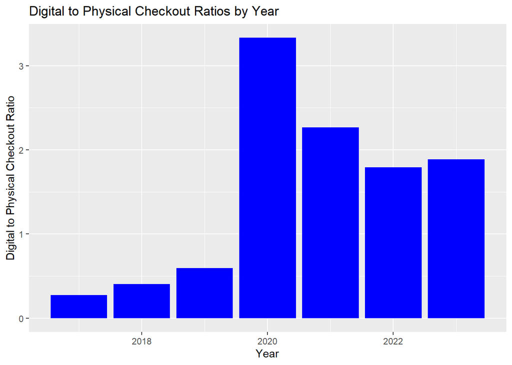

This chart displays the the ratio between digital and physical items checkout by the checkout year. I included this graph to identify changing trends in library usage and item demand. This bar chart shows that digital items initially are not checked out as much as physical items during 2017-2019. However, 2020 shows a huge spike in digital item checkouts and remains at a high value the years following. The graph shows that digital items are generally more in demand than physical items after 2020.

### Second Trends Over Time Chart

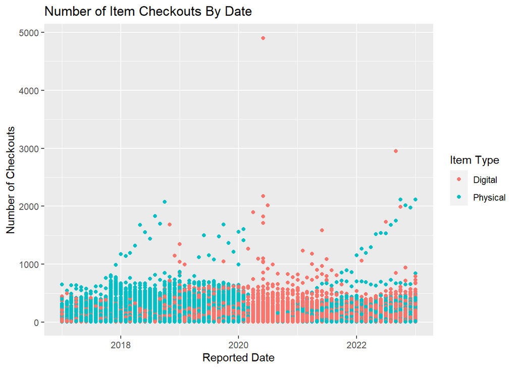

This chart displays a scatterplot displaying the amount of checkouts for an item by date. This chart features a legend showing digital and physical items. I included this chart to show trends and patterns of checkouts overtime. The scatterplot shows a massive increase in digital checkouts after 2020. Additionally, there is a generally a spike in the number of checkouts at the start of each year to the middle of the year.

### Your Choice

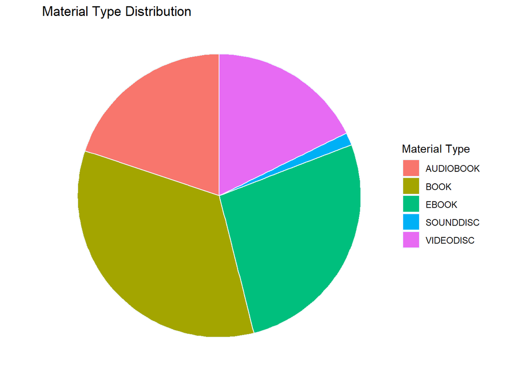